# 2020-10-24-ggplot2分面坐标轴设置问题

一般来说，ggplot可以用scale_x_continuous中的limits和breaks修改坐标轴的范围和断点，但是对于使用分面的图形，只能修改一次，而无法对于每个图形分别进行修改。这个问题困扰了我很久，以至于在很长一段时间我不得不通过AI的方式进行图面的修饰，这是一件及其烦人且没有效率的事。 但随着我仔细的阅读了ggplot2的帮助文档之后，我发现了这样一段话：

label:

- NULL for no labels
- waiver() for the default labels computed by the transformation object
- A character vector giving labels (must be same length as breaks)
- A function that takes the breaks as input and returns labels as output

limits:

- NULL to use the default scale range
- A numeric vector of length two providing limits of the scale. Use NA to refer to the existing minimum or maximum
- A function that accepts the existing (automatic) limits and returns new limits Note that setting limits on positional scales will remove data outside of the limits. If the purpose is to zoom, use the limit argument in the coordinate system (see coord_cartesian()).

output: 6933

这就表示我们可以通过尝试输入，然后看到所有输出值的最大值（或者直接通过数据确认），然后并根据这个写判断函数从而改变每个分面的标签

于是有了下面的代码：

原来的图：

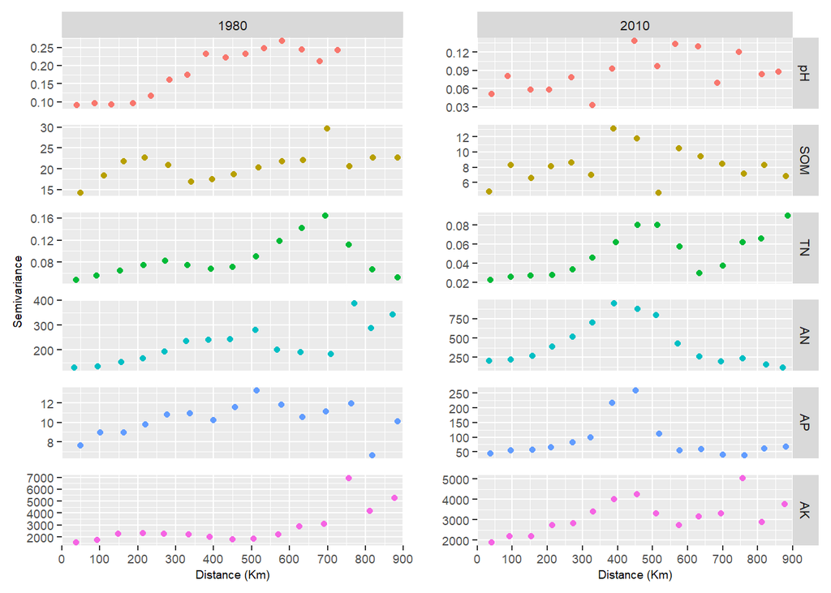

```r
p_1980<-ggplot(data=data_1980)+
  geom_point(aes(x=`X`,y=`Y`,colour=type))+
  facet_grid(type~year,scales = "free_y")+
  xlab('Distance (Km)')+ylab('Semivariance')+
  scale_x_continuous(limits=c(0,900),breaks=seq(0,900,100),expand = c(0,0))+
  theme_fig+theme(strip.text.y = element_blank())
p_2010<-ggplot(data=data_2010)+
  geom_point(aes(x=`X`,y=`Y`,colour=type))+
  facet_grid(type~year,scales = "free_y")+
  xlab('Distance (Km)')+ylab('')+
  scale_x_continuous(limits=c(0,900),breaks=seq(0,900,100),expand = c(0,0))+
  theme_fig
fig<-ggdraw()+draw_plot(p_1980, x=0, y=0, width = 0.5, height = 1)+
  draw_plot(p_2010, x=0.5, y=0, width = 0.5, height = 1)
fig
```

现在的图：

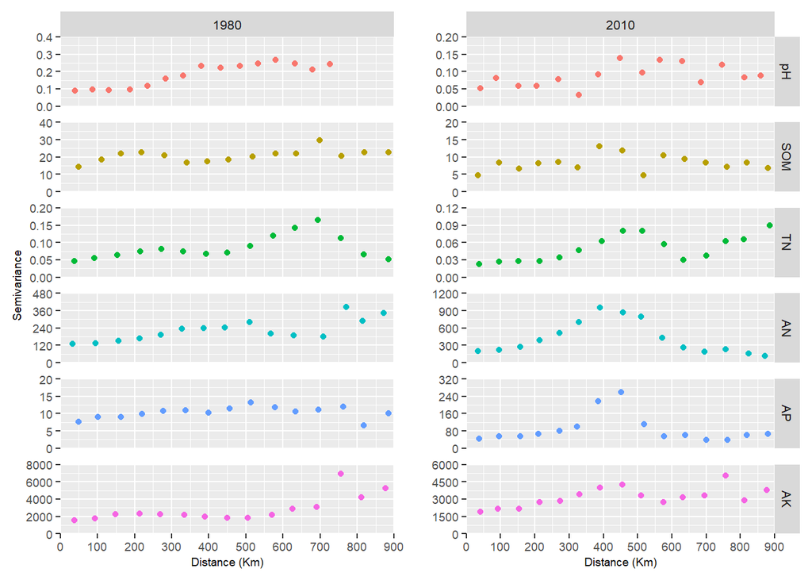

```r
LimitsFunc=function(lim){
  lim[2]<-round(lim[2],2)
  lim[1]<-0
  if(round(lim[2]==0.27)){
    lim[2]<-0.40
  }else if(lim[2]==29.71){
    lim[2]<-40
  }else if(lim[2]==0.16){
    lim[2]<-0.20
  }else if(lim[2]==387.6){
    lim[2]<-480
  }else if(lim[2]==13.27){
    lim[2]<-20
  }else if(lim[2]==6933){
    lim[2]<-8000
  }else if(lim[2]==0.14){
    lim[2]<-0.20
  }else if(lim[2]==13.11){
    lim[2]<-20
  }else if(lim[2]==0.09){
    lim[2]<-0.12
  }else if(lim[2]==950.5){
    lim[2]<-1200
  }else if(lim[2]==258.42){
    lim[2]<-320
  }else if(lim[2]==5050.49){
    lim[2]<-6000
  }else{
    print('error!')
  }
  lim
}

BreakFunc = function(lim) {
  x<-seq(lim[1], lim[2], (lim[2]-lim[1])/4)
  for (i in 1:length(x)) {
    x[i]=ifelse(x[i]<1,round(x[i],2),ifelse(x[i]<10,round(x[i],0),round(x[i],0)))
  }
  x
}
p_1980<-ggplot(data=data_1980)+
  geom_point(aes(x=`X`,y=`Y`,colour=type))+
  facet_grid(type~year,scales = "free_y")+
  xlab('Distance (Km)')+ylab('Semivariance')+
  scale_x_continuous(limits=c(0,900),breaks=seq(0,900,100),expand = c(0,0))+
  scale_y_continuous(limits=LimitsFunc,breaks = BreakFunc,
                     expand = expand_scale(mult = 0, add = 0))+
  theme_fig+theme(strip.text.y = element_blank())
p_2010<-ggplot(data=data_2010)+
  geom_point(aes(x=`X`,y=`Y`,colour=type))+
  facet_grid(type~year,scales = "free_y")+
  xlab('Distance (Km)')+ylab('')+
  scale_x_continuous(limits=c(0,900),breaks=seq(0,900,100),expand = c(0,0))+
  scale_y_continuous(limits=LimitsFunc,breaks = BreakFunc,
                     expand = expand_scale(mult = 0, add = 0))+
  theme_fig
fig<-ggdraw()+draw_plot(p_1980, x=0, y=0, width = 0.5, height = 1)+
  draw_plot(p_2010, x=0.5, y=0, width = 0.5, height = 1)
fig
```

通过修改，两个分面上的各个图标签数一致，更加符合作图规范